# Human Activity Recognition

Chang Yuan Lee

## Introduction

Machine learning methods were used to classify dumbell lifts according to the type of error in execution (if any) based on accelerometer data. Credit to Velloso, E.; Bulling, A.; Gellersen, H.; Ugulino, W.; Fuks, H. (http://groupware.les.inf.puc-rio.br/har) for the data.

The following R libraries were used.

```r
library(ggplot2)
library(caret)
library(doParallel)
library(e1071)
library(randomForest)
library(rpart)
library(rpart.plot)
library(scales)
```

## Data

First the csv files were downloaded and read.

```r
trainUrl <-"https://d396qusza40orc.cloudfront.net/predmachlearn/pml-training.csv"
testUrl <- "https://d396qusza40orc.cloudfront.net/predmachlearn/pml-testing.csv"
trainFile <- "./data/pml-training.csv"
testFile  <- "./data/pml-testing.csv"
if (!file.exists("./data")) {
  dir.create("./data")
}
if (!file.exists(trainFile)) {
  download.file(trainUrl, destfile=trainFile, method="curl")
}
if (!file.exists(testFile)) {
  download.file(testUrl, destfile=testFile, method="curl")
}
training <- read.csv("./data/pml-training.csv")
testing <- read.csv("./data/pml-testing.csv")
dim(training)
```

```
## [1] 19622   160
```

```r
dim(testing)
```

```
## [1]  20 160
```

The training set contained 19622 observations of 160 variables, and the testing set contained 20 observations.

Many of the variables would not be used for classification (such as timestamps and user names), or contained mostly blank and NA values. These were removed.

```r
remove <- grepl("^X|user|timestamp|window", names(training))
training <- training[, !remove]
remove <- grepl("^X|user|timestamp|window|problem", names(testing))
testing <- testing[, !remove]
remove <- which(colSums(is.na(training) | training=="") > 100)
training <- training[, -remove]
testing <- testing[, -remove]
dim(training)
```

```
## [1] 19622    53
```

```r
dim(testing)
```

```
## [1] 20 52
```

Only 52 predictor variables remained after data cleaning.

The data was converted into data frames containing numeric data, with the exception of the “classe” variable.

```r
classe <- training$classe
training <- data.frame(data.matrix(training))
training$classe <- classe
testing <- data.frame(data.matrix(testing))
```

The training data was then split into a training set (80%) and a validation set (20%).

```r
set.seed(12345)
inTrain <- createDataPartition(training$classe, p=0.80, list=FALSE)
validation <- training[-inTrain, ]
training <- training[inTrain, ]
```

## Model

The random forest method was chosen for the machine learning model due to its high accuracy and manageable computational complexity for a data set of this size, especially since interpretability was not a requirement for this task. Parallel processing was used to improve training speed.

```r
clust <- makeCluster(detectCores())
registerDoParallel(clust)
model <- train(classe ~ ., data=training, method="rf", ntree=200)
pred1 <- predict(model, validation)
stopCluster(clust)
model
```

```
## Random Forest
##
## 15699 samples
##    52 predictor
##     5 classes: 'A', 'B', 'C', 'D', 'E'
##
## No pre-processing
## Resampling: Bootstrapped (25 reps)
## Summary of sample sizes: 15699, 15699, 15699, 15699, 15699, 15699, ...
## Resampling results across tuning parameters:
##
##   mtry  Accuracy   Kappa
##    2    0.9899829  0.9873295
##   27    0.9908578  0.9884359
##   52    0.9821546  0.9774272
##
## Accuracy was used to select the optimal model using the largest value.
## The final value used for the model was mtry = 27.
```

Accuracy and out-of-sample error rate of the model was estimated using the validation set.

```r
confusion <- confusionMatrix(validation$classe, pred1)
confusion$overall[c(1, 3, 4)]
```

```
##      Accuracy AccuracyLower AccuracyUpper
##     0.9943920     0.9915217     0.9964823
```

The accuracy is 99.4% with a 95% confidence interval between 99.1% and 99.6% accuracy.

The out-of-sample error rate is:

```r
percent(1 - as.numeric(confusion$overall[1]))
```

```
## [1] "0.561%"
```

## Prediction

Finally, the model was used to predict the classes of the testing set.

```r
pred2 <- predict(model, testing)
results <- data.frame("Class" = pred2)
results
```

```
##    Class
## 1      B
## 2      A
## 3      B
## 4      A
## 5      A
## 6      E
## 7      D
## 8      B
## 9      A
## 10     A
## 11     B
## 12     C
## 13     B
## 14     A
## 15     E
## 16     E
## 17     A
## 18     B
## 19     B
## 20     B
```

## Appendix

Visualization of the type of decision tree used by the random forest method.

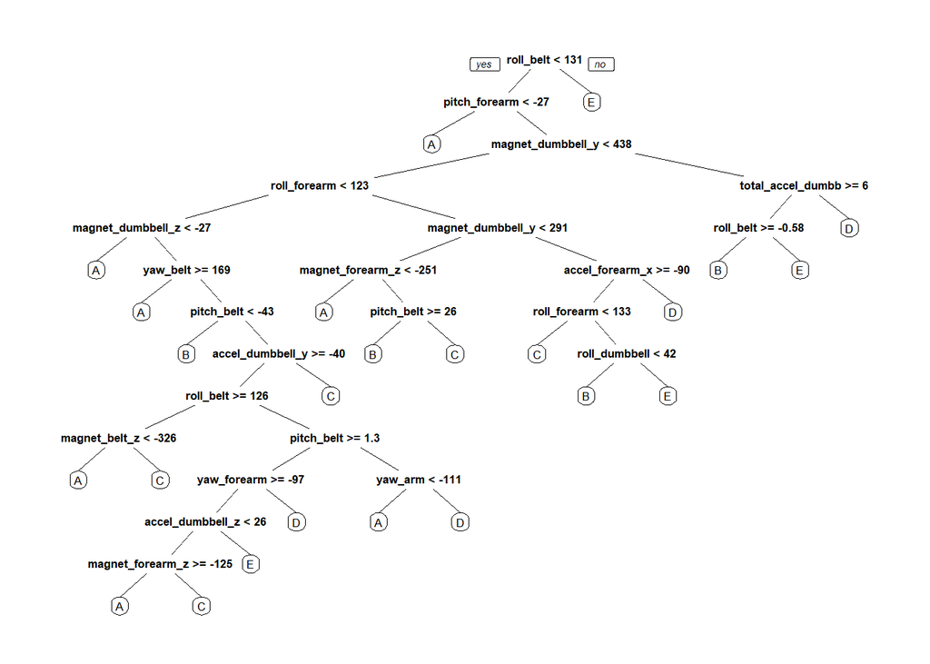

```r
tree <- rpart(classe ~ ., data = training, method = "class")
prp(tree)
```

Plot of the error rate of the final model.

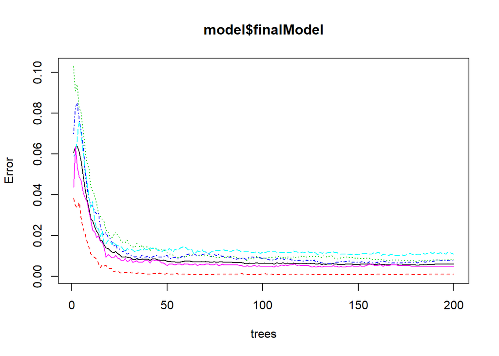

```r
plot(model$finalModel)
```

Confusion matrix of the model

```r
confusion
```

```
## Confusion Matrix and Statistics
##
##           Reference
## Prediction    A    B    C    D    E
##          A 1116    0    0    0    0
##          B    6  752    1    0    0
##          C    0    2  680    2    0
##          D    0    0    8  634    1
##          E    0    0    1    1  719
##
## Overall Statistics
##
##                Accuracy : 0.9944
##                  95% CI : (0.9915, 0.9965)
##     No Information Rate : 0.286
##     P-Value [Acc > NIR] : < 2.2e-16
##
##                   Kappa : 0.9929
##
##  Mcnemar's Test P-Value : NA
##
## Statistics by Class:
##
##                      Class: A Class: B Class: C Class: D Class: E
## Sensitivity            0.9947   0.9973   0.9855   0.9953   0.9986
## Specificity            1.0000   0.9978   0.9988   0.9973   0.9994
## Pos Pred Value         1.0000   0.9908   0.9942   0.9860   0.9972
## Neg Pred Value         0.9979   0.9994   0.9969   0.9991   0.9997
## Prevalence             0.2860   0.1922   0.1759   0.1624   0.1835
## Detection Rate         0.2845   0.1917   0.1733   0.1616   0.1833
## Detection Prevalence   0.2845   0.1935   0.1744   0.1639   0.1838
## Balanced Accuracy      0.9973   0.9976   0.9921   0.9963   0.9990
```